# Quantile Regression Analysis

Demographic and Socioeconomic Predictors of Algebra 1 End-of-Course Achievement in Florida School Districts  
**Advisor:** Dr. Cohen

Authors

Wendy Matende

Madison Edwards

Jegg Ononiewu

Published

July 14, 2026

Slides

# Introduction

Algebra 1 is widely recognized as a foundational gateway course in secondary mathematics, shaping students’ access to advanced coursework and long term academic opportunities. Success in Algebra 1 is strongly associated with readiness for higher level mathematics, college preparation, and career pathways in science, technology, engineering, and mathematics (STEM) fields. In Florida, the stakes are particularly high because students must pass the Algebra 1 End-of-Course (EOC) assessment or earn an approved comparative score to satisfy the graduation requirement for a standard high school diploma. In addition, the EOC assessment contributes 30% of a student’s final course grade and serves an important role in school accountability and instructional decision-making. As noted in Florida Department of Education guidance, the assessment influences “course completion, graduation, school accountability, and decisions about remediation and student support.”

Florida’s 67 school districts vary considerably in their demographic and socioeconomic composition, including racial and ethnic distributions, poverty levels, unemployment rates, household income, and educational attainment. These contextual characteristics have long been associated with differences in educational outcomes, particularly mathematics achievement. Students living in economically disadvantaged communities often experience structural barriers that may limit academic success, whereas districts with greater socioeconomic resources may provide conditions that better support student learning and achievement. Understanding how these community characteristics relate to student performance is therefore essential for developing equitable educational policies and interventions.

Previous research suggests that demographic and socioeconomic influences on achievement are complex and may not operate uniformly across all levels of student performance. Tian (2006) found that family background and socioeconomic characteristics affect lower-achieving and higher-achieving students differently, suggesting that contextual influences vary across the achievement distribution. Similarly, Haile and Nguyen (2008) reported that ethnicity-related effects differ across performance levels, indicating that analyses focused solely on average outcomes may obscure important variation. Reeves and Lowe (2009) further cautioned that mean-based statistical models can encourage “one-size-fits-all” interpretations by masking meaningful differences among lower, middle, and higher-performing groups. Despite these findings, most studies examining predictors of mathematics achievement continue to rely on ordinary least squares (OLS) regression, which estimates average relationships and assumes that predictor effects remain constant across the entire outcome distribution. In contrast, quantile regression estimates relationships at multiple points of the distribution, allowing researchers to determine whether predictors exert stronger, weaker, or qualitatively different effects among lower, middle, and higher-performing districts.

Although quantile regression has been applied in a variety of educational settings, relatively little research has examined district level Algebra 1 EOC achievement using this approach, particularly within Florida. Existing Florida studies, including Holley (2017), have explored factors associated with Algebra 1 EOC performance but have primarily relied on traditional mean-based statistical methods. Consequently, an important gap remains in understanding whether demographic and socioeconomic characteristics influence Algebra 1 achievement differently across districts with varying levels of academic performance. As noted in prior work, statewide averages “cannot show whether the same relationships appear in lower, middle, and higher-performing districts,” highlighting the need for analyses that account for differences across the achievement distribution.

Addressing this gap, the present study examines how district level demographic characteristics (White, Black, and Hispanic population estimates) and socioeconomic characteristics (poverty rate, unemployment rate, median household income, and bachelor’s degree attainment) are associated with Algebra 1 EOC achievement across Florida school districts and whether these relationships differ across lower, middle, and higher-achievement quantiles. Quantile regression is employed to estimate the effects of these predictors at multiple points of the achievement distribution, providing a more comprehensive understanding of how contextual factors relate to mathematics performance than traditional mean-based approaches.

Specifically, this study addresses the following research questions:

1. How are district-level demographic characteristics associated with Algebra 1 EOC achievement?
2. How are district-level socioeconomic characteristics associated with Algebra 1 EOC achievement?
3. Do the direction, magnitude, and statistical significance of these predictors vary across the achievement distribution when examined using quantile regression?
4. Which predictors demonstrate the strongest associations at specific quantiles, and what implications do these patterns hold for equity-focused district planning and decision-making?

The findings of this study have practical implications for educational leaders, policymakers, and researchers. Identifying whether particular demographic or socioeconomic characteristics exert stronger influences among lower-performing or higher-performing districts may support more targeted resource allocation, equity-focused planning, and evidence-based decision-making. For educators, the results provide insight into how community context may shape mathematics achievement and can inform efforts to reduce disparities in student outcomes. For researchers, this study extends the application of quantile regression within K–12 educational research while addressing a documented gap in the Florida Algebra 1 EOC literature. By examining achievement through a distribution-sensitive lens, this study contributes to a more nuanced understanding of how demographic and socioeconomic conditions are associated with mathematics performance and offers evidence that may inform policies and interventions designed to promote educational success across Florida’s diverse school districts.

Although previous studies have examined factors associated with mathematics achievement, relatively few have investigated whether these relationships differ across the distribution of district level Algebra 1 End of Course achievement in Florida. By applying quantile regression, this study extends previous research by examining whether demographic and socioeconomic characteristics have different associations with achievement among lower, middle, and higher-performing school districts. This distribution-based approach provides a more complete understanding of educational inequality than traditional mean-based regression and offers evidence that may support more targeted educational policies and interventions.

# METHODS

### Quantile Regression

Quantile regression (QR), introduced by Koenker and Bassett (1978), is a statistical method used to estimate conditional quantiles of a response variable rather than only its conditional mean. Unlike Ordinary Least Squares (OLS) regression, which estimates the average relationship between a response variable and a set of explanatory variables, quantile regression estimates relationships at different points of the outcome distribution. This allows researchers to examine whether the effects of explanatory variables differ among lower, middle, and upper-performing observations Koenker and Hallock (2001).

One of the main advantages of quantile regression is that it provides more information than mean-based regression. OLS assumes that the relationship between the response variable and the explanatory variables is the same across the entire distribution. However, this assumption is not always appropriate. Reeves and Lowe (2009) explain that OLS regression coefficients may be misleading because they describe only the average relationship, whereas quantile regression allows variation across the conditional distribution to be examined. Similarly, Costanzo and Desimoni (2017) state that mean-based models represent only part of the information needed to understand complex educational outcomes because relationships between variables may differ across performance levels.

For a quantile level $\tau$, where $0 < \tau < 1$, the conditional quantile regression model is expressed as

$$Q_Y(\tau|X)=X^{T}\beta(\tau),$$

where $Q_Y(\tau|X)$ represents the conditional quantile of the response variable, $X$ represents the explanatory variables, and $\beta(\tau)$ is the vector of regression coefficients for the selected quantile. Unlike OLS regression, which estimates one set of regression coefficients for the conditional mean, quantile regression estimates a different set of coefficients for each quantile. This allows researchers to examine how the effects of explanatory variables change across the distribution of the response variable Koenker and Ng (2005).

The regression coefficients are estimated by minimizing an asymmetrically weighted sum of absolute residuals instead of the sum of squared residuals used in OLS regression. The estimator is defined as

$$\hat{\beta}(\tau)=\arg\min_{\beta}\sum_{i=1}^{n}\rho_{\tau}(y_i-x_i^{T}\beta),$$

where the check-loss function is

$$\rho_{\tau}(u)=u[\tau-I(u<0)],$$

and $I(\cdot)$ is the indicator function Koenker and Bassett (1978). This estimation method gives different weights to positive and negative residuals depending on the quantile being estimated. As a result, the model is estimated using linear programming methods rather than least-squares estimation Buhai (2004).

Another advantage of quantile regression is that it does not require the assumptions of normality or constant error variance that are commonly associated with OLS regression. Therefore, it performs well when the data are skewed, when the variability changes across the distribution, or when outliers are present (Lê Cook and Manning (2013); Waldmann (2018)). Davino et al. (2013) also explain that quantile regression makes it possible to study changes in the location, spread, and shape of the conditional distribution, providing information that cannot be obtained from mean regression alone.

The interpretation of quantile regression coefficients is similar to that of OLS regression but applies to a specific conditional quantile rather than the conditional mean. A coefficient represents the expected change in the selected conditional quantile of the response variable associated with a one-unit increase in an explanatory variable, while holding all other variables constant. Because a separate model is estimated for each quantile, the estimated effects may differ across the distribution. Haile and Nguyen (2008) and Petscher and Logan (2014) note that this allows researchers to determine whether relationships are stronger, weaker, or different across lower, middle, and upper-performing groups.

Quantile regression has been widely applied in economics, education, public health, and other social science disciplines. According to Koenker and Hallock (2001), Lê Cook and Manning (2013), and Beyerlein (2014), the method is especially useful when researchers are interested in understanding relationships across the entire distribution of an outcome rather than only its average. By estimating several conditional quantiles, quantile regression provides a more complete understanding of the relationship between explanatory variables and the response variable.

The quantile regression models are estimated using the quantreg package in R, which implements the estimation procedure developed by Koenker and Bassett (1978). The package estimates regression coefficients using linear programming algorithms to solve the quantile optimization problem. Because the check-loss function is not smooth at zero, standard errors are commonly obtained using bootstrap methods, as recommended by Koenker and Ng (2005). This approach provides reliable statistical inference for the estimated quantile regression coefficients.

# Modeling and Data Analysis

## Data Preparation

Before statistical modeling, the Spring 2024 Florida Algebra 1 End-of-Course (EOC) assessment data were merged with the 2023 American Community Survey (ACS) 5-Year Estimates using county identifiers, as most Florida public school districts correspond to county boundaries. Districts with missing or suppressed achievement data were excluded, resulting in a final analytic sample of 66 Florida school districts.

The merged dataset was cleaned and standardized before analysis. Variables were renamed to improve consistency, with the district mean Algebra 1 EOC scale score renamed `Mean_Score` and the percentage of students scoring at Level 3 or above renamed `Level3Plus`. Character variables were converted to numeric format where necessary, and ACS population counts were transformed into percentages or rates to facilitate comparisons across districts. The final dataset included the demographic variables `pct_white`, `pct_black`, and `pct_hispanic`, together with the socioeconomic variables `poverty_rate`, `unemployment_rate`, `median_income`, and `bachelors_rate`. All data preparation and statistical analyses were conducted using R.Because Florida school districts generally correspond to county boundaries, county-level ACS estimates provide appropriate district-level demographic and socioeconomic measures for this analysis.

Below is the complete data processing program used to ingest, format, and merge the target education records and census fields.

**▶ Data Cleaning and Preparation Code**

**View R Code**

```r
library(tidyverse)
```

**View R Code**

```r
library(tidycensus)
library(janitor)
```

**View R Code**

```r
library(readxl)
library(dplyr)

eoc_raw <- read_excel("34Spring24Alg1SRD (1).xls", skip = 4)

eoc_clean <- eoc_raw %>%
mutate(`District Number` = as.numeric(`District Number`)) %>%
filter(`District Number` >= 1 & `District Number` <= 67)

eoc_clean2 <- eoc_clean %>%
filter(Grade == "All Grades")

library(tidyverse)
library(tidycensus)
library(readxl)
library(dplyr)
library(tidyr)

readRenviron("~/.Renviron")

acs_raw <- get_acs(
geography = "county",
state = "FL",
survey = "acs5",
year = 2023,
variables = c(
total_pop = "B03002_001",

white = "B03002_003",
black = "B03002_004",
hispanic = "B03002_012",

poverty_total = "B17001_001",
poverty = "B17001_002",

labor_force = "B23025_003",
unemployed = "B23025_005",

pop25plus = "B15003_001",
bachelors = "B15003_022",

median_income = "B19013_001"
)
)
```

**View R Code**

```r
acs_wide <- acs_raw %>%
select(GEOID, NAME, variable, estimate) %>%
pivot_wider(
names_from = variable,
values_from = estimate
)

acs_wide <- acs_wide %>%
mutate(
pct_white = 100 * white / total_pop,
pct_black = 100 * black / total_pop,
pct_hispanic = 100 * hispanic / total_pop,
poverty_rate = 100 * poverty / poverty_total,
unemployment_rate = 100 * unemployed / labor_force,
bachelors_rate = 100 * bachelors / pop25plus
)

acs_final <- acs_wide %>%
select(
GEOID,
NAME,
pct_white,
pct_black,
pct_hispanic,
poverty_rate,
unemployment_rate,
median_income,
bachelors_rate
)

acs_final <- acs_final %>%
mutate(
District_Name = toupper(gsub(" County, Florida", "", NAME))
)

eoc_clean2 <- eoc_clean2 %>%
mutate(
District_Name = toupper(`District Name`)
)


final_data2 <- eoc_clean2 %>%
left_join(
acs_final,
by = "District_Name"
)

final_data2 <- final_data2[-34, ]
```

## Model Specification

To examine the relationship between district demographic and socioeconomic characteristics and Algebra 1 achievement, an **Ordinary Least Squares (OLS)** regression model was estimated as a baseline for comparison. The primary analysis used **Quantile Regression (QR)** to examine relationships across the achievement distribution.. The OLS model was first fitted to estimate the average relationship between the explanatory variables and district mean Algebra 1 EOC achievement. The OLS model is expressed as:

$$\begin{aligned}
Y_i = {} & \beta_0 + \beta_1(\text{pct\_white}) + \beta_2(\text{pct\_black}) + \beta_3(\text{pct\_hispanic}) \\
& + \beta_4(\text{poverty\_rate}) + \beta_5(\text{unemployment\_rate}) + \beta_6(\text{median\_income}) \\
& + \beta_7(\text{bachelors\_rate}) + \varepsilon_i
\end{aligned}$$

where $Y_i$ represents the district mean Algebra 1 EOC scale score, $\beta_0$ is the intercept, $\beta_1$–$\beta_7$ are the regression coefficients, and $\varepsilon_i$ is the random error term.

To investigate whether these relationships varied across different levels of district achievement, Quantile Regression models were estimated at the 10th, 25th, 50th, 75th, and 90th quantiles. The Quantile Regression model is specified as:

$$\begin{aligned}
Q_{\tau}(Y|X) = {} & \beta_{0}(\tau) + \beta_{1}(\tau)\text{pct\_white} + \beta_{2}(\tau)\text{pct\_black} + \beta_{3}(\tau)\text{pct\_hispanic} \\
& + \beta_{4}(\tau)\text{poverty\_rate} + \beta_{5}(\tau)\text{unemployment\_rate} \\
& + \beta_{6}(\tau)\text{median\_income} + \beta_{7}(\tau)\text{bachelors\_rate}
\end{aligned}$$

where $Q_{\tau}(Y|X)$ denotes the conditional quantile of the district mean Algebra 1 EOC scale score at quantile $\tau$, $X$ represents the vector of demographic and socioeconomic predictors, and $\beta(\tau)$ denotes the quantile-specific regression coefficients.

Both the OLS and Quantile Regression models included the same set of explanatory variables, allowing direct comparison between average effects estimated by OLS and distribution-specific effects estimated by Quantile Regression. Quantile regression models were estimated at $\tau = 0.10, 0.25, 0.50, 0.75,$ and $0.90$, representing lower-, lower-middle-, median-, upper-middle-, and higher-performing school districts, respectively.

## Data Analysis

Data analysis was conducted in four stages using R.

First, exploratory data analysis was performed to examine the distribution of district Algebra 1 achievement and the relationships between achievement and selected demographic and socioeconomic variables. A histogram was used to assess the distribution of district mean scale scores, while scatterplots with fitted linear trend lines were used to visualize the bivariate relationships between `Mean_Score` and poverty rate, median household income, bachelor’s degree attainment, and unemployment rate.

Second, Pearson correlation analysis was conducted to examine associations among the study variables and to assess potential multicollinearity before fitting the regression models.

Third, an Ordinary Least Squares (OLS) regression model was estimated using the `lm()` function in R to evaluate the average effects of demographic and socioeconomic characteristics on district Algebra 1 achievement.

Finally, Quantile Regression models were estimated using the `quantreg` package in R through the `rq()` function at the 10th, 25th, 50th, 75th, and 90th quantiles. Estimating multiple quantiles enabled the examination of how predictor effects differed across lower-, middle-, and higher-achieving districts, providing insights that cannot be obtained from mean-based regression alone. Statistical significance for both OLS and Quantile Regression models was evaluated at the 5% significance level ($\alpha = 0.05$).

## Results and Discussion

This section presents the findings of the study in the order of the analyses conducted. Each subsection briefly describes the statistical results, provides interpretation, situates findings within existing literature, and explicitly connects outcomes to the research questions.

**View R Code**

```r
final_data2 <- final_data2 %>%
rename(
Mean_Score = `Mean Scale Score`,
Level3Plus = `Percentage in \nLevel 3 or Above`
)
```

**View R Code**

```r
final_data2$Mean_Score <- as.numeric(trimws(final_data2$Mean_Score))
```

### Distribution of Algebra 1 Mean Scale Scores (Figure 1)

**View R Code**

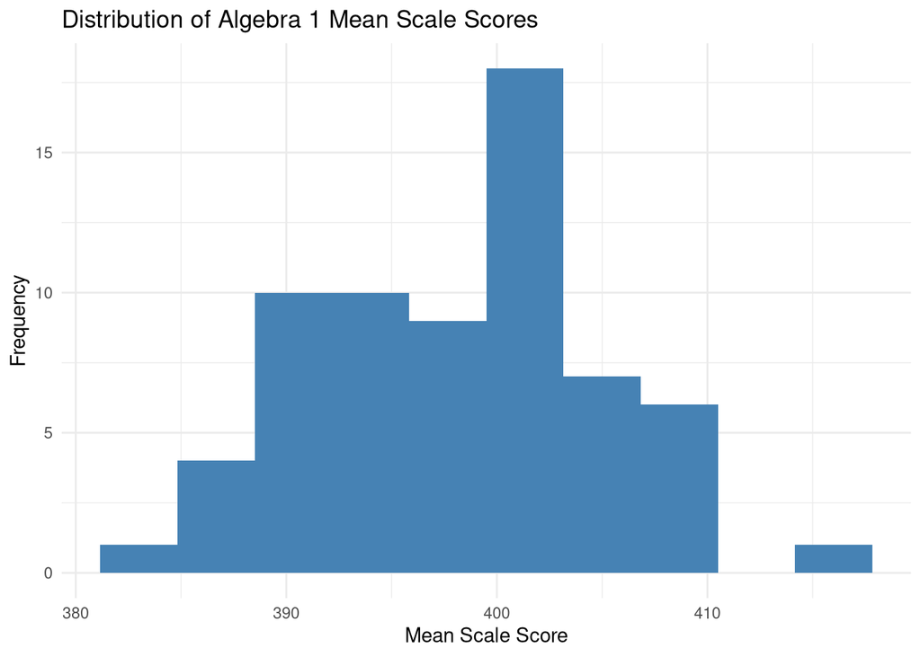

```r
ggplot(final_data2, aes(x = Mean_Score)) +
geom_histogram(bins = 10, fill = "steelblue") +
labs(
title = "Distribution of Algebra 1 Mean Scale Scores",
x = "Mean Scale Score",
y = "Frequency"
) +
theme_minimal()
```

### Distribution of Algebra 1 Mean Scale Scores (Figure 1)

Figure 1 shows that district-level Algebra 1 mean scale scores are tightly clustered between approximately 390 and 405, with limited variation across Florida school districts.

This narrow distribution suggests that most districts perform close to the state average, reflecting standardized assessment conditions and statewide accountability structures that reduce variability in outcomes. However, even within a compressed range, small differences in performance may reflect meaningful underlying socioeconomic inequalities.

This pattern is consistent with Reardon et al. (2019), who notes that district-level achievement distributions often appear compressed due to standardized systems, yet still mask persistent socioeconomic gradients. Similarly, Sirin (2005) emphasizes that socioeconomic status continues to explain variation even when overall dispersion is limited.

### Poverty and Algebra 1 Achievement (Figure 2)

**View R Code**

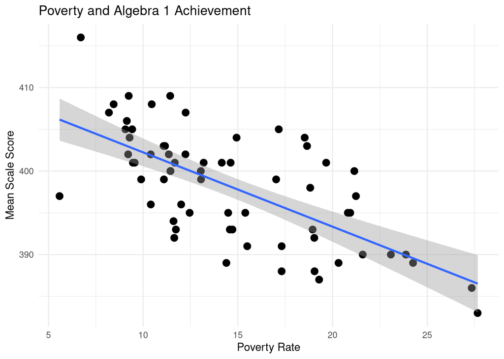

```r
ggplot(final_data2, aes(x = poverty_rate, y = Mean_Score)) +
geom_point(size = 3) +
geom_smooth(method = "lm") +
labs(
title = "Poverty and Algebra 1 Achievement",
x = "Poverty Rate",
y = "Mean Scale Score"
) +
theme_minimal()
```

Figure 2 shows a negative relationship between poverty and Algebra 1 achievement, with higher-poverty districts generally exhibiting lower mean scores.

This suggests that socioeconomic disadvantage is associated with lower academic performance. However, poverty loses statistical significance in the multivariate model, indicating that its effect overlaps with other socioeconomic variables such as income and educational attainment.

This finding aligns with Sirin (2005) and Reardon et al. (2019), who argue that poverty reflects broader structural disadvantage rather than acting independently.

### Median Household Income (Figure 3)

**View R Code**

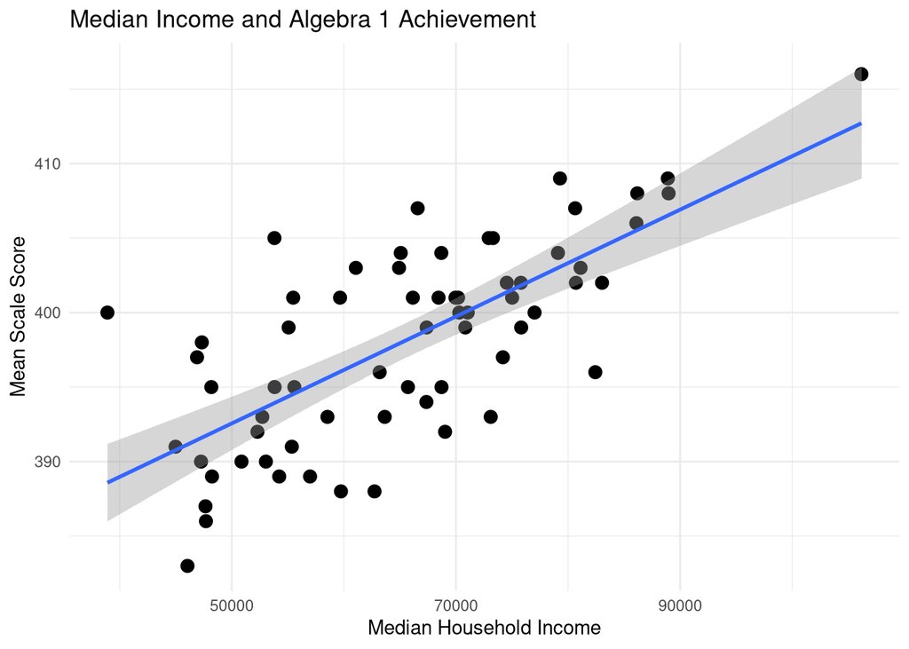

```r
ggplot(final_data2, aes(x = median_income, y = Mean_Score)) +
geom_point(size = 3) +
geom_smooth(method = "lm") +
labs(
title = "Median Income and Algebra 1 Achievement",
x = "Median Household Income",
y = "Mean Scale Score"
) +
theme_minimal()
```

Figure 3 shows a clear positive association between median household income and Algebra 1 achievement.

Districts with higher income levels tend to perform better academically, although this relationship becomes statistically insignificant in the multivariate model due to strong correlation with educational attainment.

This is consistent with Reardon et al. (2019) and Duncan and Murnane (2016), who show that income strongly predicts achievement but often operates through correlated socioeconomic pathways.

### Bachelor’s Degree Attainment (Figure 4)

**View R Code**

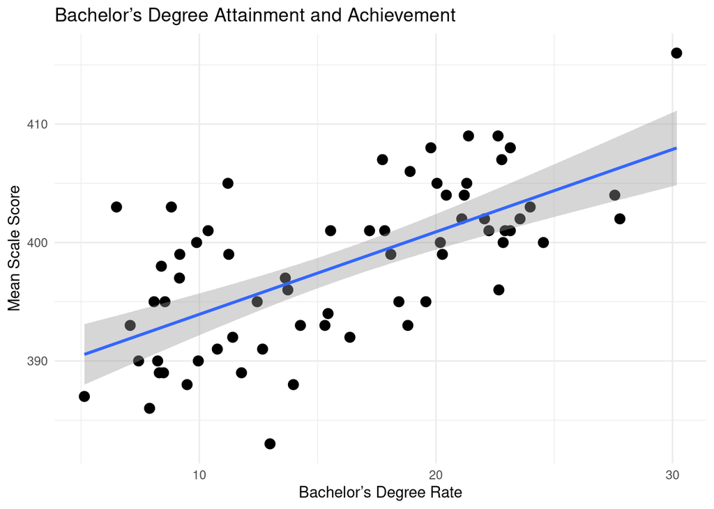

```r
ggplot(final_data2, aes(x = bachelors_rate, y = Mean_Score)) +
geom_point(size = 3) +
geom_smooth(method = "lm") +
labs(
title = "Bachelor’s Degree Attainment and Achievement",
x = "Bachelor’s Degree Rate",
y = "Mean Scale Score"
) +
theme_minimal()
```

Figure 4 shows a strong positive relationship between bachelor’s degree attainment and Algebra 1 achievement.

This supports Sirin (2005),and Reardon et al. (2019), who emphasize parental education as a key driver of student success.

One possible explanation is that districts with higher levels of adult educational attainment may provide stronger educational support systems, higher academic expectations, and greater access to educational resources. These community characteristics may create learning environments that support higher levels of mathematics achievement, particularly among higher-performing districts.

### Unemployment (Figure 5)

**View R Code**

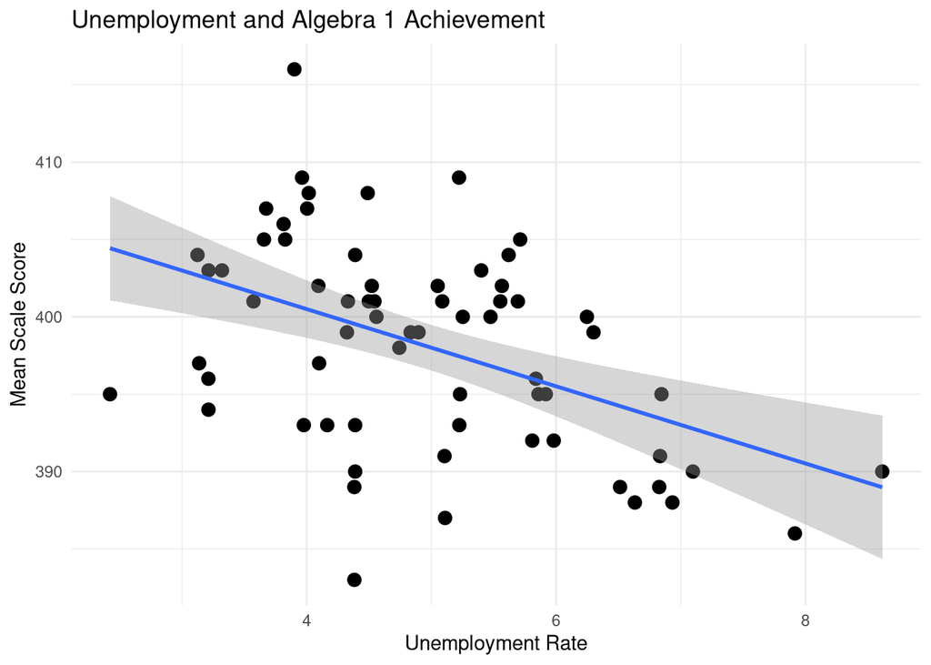

```r
ggplot(final_data2, aes(x = unemployment_rate, y = Mean_Score)) +
geom_point(size = 3) +
geom_smooth(method = "lm") +
labs(
title = "Unemployment and Algebra 1 Achievement",
x = "Unemployment Rate",
y = "Mean Scale Score"
) +
theme_minimal()
```

Figure 5 shows a clear negative relationship between unemployment and Algebra 1 achievement.

Districts with higher unemployment rates consistently show lower achievement levels. Unlike poverty and income, unemployment remains statistically significant in the OLS model.

This finding aligns with Duncan and Murnane (2016), who show that economic instability directly affects student learning environments.

Higher unemployment may reduce household financial stability, increase stress within families, and limit access to educational opportunities and learning resources. These conditions may contribute to lower student achievement across districts regardless of overall performance level.

### OLS Regression Results

**View R Code**

```r
ols_model2 <- lm(
Mean_Score ~
pct_white +
pct_black +
pct_hispanic +
poverty_rate +
unemployment_rate +
median_income +
bachelors_rate,
data = final_data2
)

summary(ols_model2)
```

```
Call:
lm(formula = Mean_Score ~ pct_white + pct_black + pct_hispanic +
    poverty_rate + unemployment_rate + median_income + bachelors_rate,
    data = final_data2)

Residuals:
   Min     1Q Median     3Q    Max
-9.231 -2.880 -0.526  2.925  9.990

Coefficients:
                    Estimate Std. Error t value Pr(>|t|)
(Intercept)        4.099e+02  3.124e+01  13.120   <2e-16 ***
pct_white         -1.943e-01  3.166e-01  -0.614   0.5419
pct_black         -3.601e-01  3.318e-01  -1.085   0.2823
pct_hispanic      -2.475e-01  3.123e-01  -0.793   0.4313
poverty_rate       5.571e-02  2.427e-01   0.230   0.8193
unemployment_rate -1.259e+00  5.278e-01  -2.386   0.0203 *
median_income      1.355e-04  9.654e-05   1.403   0.1659
bachelors_rate     3.781e-01  1.815e-01   2.084   0.0416 *
---
Signif. codes:  0 '***' 0.001 '**' 0.01 '*' 0.05 '.' 0.1 ' ' 1

Residual standard error: 4.439 on 58 degrees of freedom
Multiple R-squared:  0.6105,    Adjusted R-squared:  0.5635
F-statistic: 12.99 on 7 and 58 DF,  p-value: 6.464e-10
```

The OLS regression shows that only unemployment and bachelor’s degree attainment are statistically significant predictors of Algebra 1 achievement.

These findings suggest that, after accounting for the overlap among demographic and socioeconomic variables, unemployment and educational attainment remain the strongest independent predictors of district Algebra 1 achievement. Although poverty and median household income are associated with achievement in the bivariate analyses, their effects appear to be shared with other socioeconomic characteristics included in the model. This finding highlights the importance of considering multiple indicators simultaneously when examining educational outcomes.

Poverty, income, and demographic variables lose significance once all variables are included, suggesting overlapping explanatory power among SES indicators.

This reflects a limitation of mean-based regression, which assumes uniform effects across all districts. Koenker and Bassett (1978), highlight that this assumption may obscure important variation across the distribution.

Although the OLS model identifies the average relationship between the predictors and Algebra 1 achievement, these average effects may conceal important differences across districts with different performance levels. To determine whether the effects of demographic and socioeconomic characteristics vary across the achievement distribution, quantile regression models were estimated at five conditional quantiles.

### Quantile Regression Analysis

Quantile regression was used to determine whether the effects of demographic and socioeconomic characteristics differ across the distribution of district Algebra 1 achievement. Unlike OLS regression, which estimates a single average relationship, quantile regression estimates separate models at different points of the achievement distribution. Models were estimated at $\tau = 0.10$, $\tau = 0.25$, $\tau = 0.50$, $\tau = 0.75$, and $\tau = 0.90$, representing lower-, lower-middle-, median-, upper-middle-, and higher-performing school districts. This approach makes it possible to identify differences in predictor effects that are not visible in average-based regression models.

**View R Code**

```r
final_data2 <- final_data2 %>%
mutate(
Mean_Score = as.numeric(Mean_Score),
Level3Plus = as.numeric(Level3Plus)
)
```

**View R Code**

```r
library(quantreg)
```

**View R Code**

```r
rq10 <- rq(
Mean_Score ~
pct_white +
pct_black +
pct_hispanic +
poverty_rate +
unemployment_rate +
median_income +
bachelors_rate,
tau = .10,
data = final_data2
)

rq25 <- rq(
Mean_Score ~
pct_white +
pct_black +
pct_hispanic +
poverty_rate +
unemployment_rate +
median_income +
bachelors_rate,
tau = .25,
data = final_data2
)

rq50 <- rq(
Mean_Score ~
pct_white +
pct_black +
pct_hispanic +
poverty_rate +
unemployment_rate +
median_income +
bachelors_rate,
tau = .50,
data = final_data2
)

rq75 <- rq(
Mean_Score ~
pct_white +
pct_black +
pct_hispanic +
poverty_rate +
unemployment_rate +
median_income +
bachelors_rate,
tau = .75,
data = final_data2
)

rq90 <- rq(
Mean_Score ~
pct_white +
pct_black +
pct_hispanic +
poverty_rate +
unemployment_rate +
median_income +
bachelors_rate,
tau = .90,
data = final_data2
)

summary(rq10)
```

```
Call: rq(formula = Mean_Score ~ pct_white + pct_black + pct_hispanic +
    poverty_rate + unemployment_rate + median_income + bachelors_rate,
    tau = 0.1, data = final_data2)

tau: [1] 0.1

Coefficients:
                  coefficients lower bd  upper bd
(Intercept)       469.34428    391.24226 539.91895
pct_white          -0.83163     -1.64835  -0.02813
pct_black          -0.88331     -1.89544  -0.31056
pct_hispanic       -0.81958     -1.51496   0.52207
poverty_rate       -0.16454     -1.00658   0.99221
unemployment_rate  -1.03063     -1.94858  -0.05861
median_income       0.00006     -0.00028   0.00058
bachelors_rate      0.32599     -0.43910   1.02728
```

**View R Code**

```r
summary(rq25)
```

```
Call: rq(formula = Mean_Score ~ pct_white + pct_black + pct_hispanic +
    poverty_rate + unemployment_rate + median_income + bachelors_rate,
    tau = 0.25, data = final_data2)

tau: [1] 0.25

Coefficients:
                  coefficients lower bd  upper bd
(Intercept)       414.50273    292.67112 545.91974
pct_white          -0.41076     -1.43843   0.76062
pct_black          -0.59146     -1.28271   0.53484
pct_hispanic       -0.45779     -1.49780   0.69455
poverty_rate        0.25181     -0.22999   0.82890
unemployment_rate  -1.26964     -1.91763   0.69278
median_income       0.00032     -0.00007   0.00050
bachelors_rate      0.22241      0.00447   0.99523
```

**View R Code**

```r
summary(rq50)
```

```
Call: rq(formula = Mean_Score ~ pct_white + pct_black + pct_hispanic +
    poverty_rate + unemployment_rate + median_income + bachelors_rate,
    tau = 0.5, data = final_data2)

tau: [1] 0.5

Coefficients:
                  coefficients lower bd  upper bd
(Intercept)       387.18481    327.67107 439.22643
pct_white          -0.04939     -0.45832   0.57221
pct_black          -0.23560     -0.69047   0.59324
pct_hispanic       -0.16630     -0.46464   0.52607
poverty_rate        0.27313     -0.32569   0.48568
unemployment_rate  -1.57250     -2.10541   0.12394
median_income       0.00026     -0.00006   0.00033
bachelors_rate      0.38489     -0.10467   0.76456
```

**View R Code**

```r
summary(rq75)
```

```
Call: rq(formula = Mean_Score ~ pct_white + pct_black + pct_hispanic +
    poverty_rate + unemployment_rate + median_income + bachelors_rate,
    tau = 0.75, data = final_data2)

tau: [1] 0.75

Coefficients:
                  coefficients lower bd  upper bd
(Intercept)       337.93925    285.25624 473.69658
pct_white           0.53404     -0.98886   1.04486
pct_black           0.58432     -1.22048   1.14585
pct_hispanic        0.41504     -0.49983   1.00067
poverty_rate        0.08648     -0.25965   0.62059
unemployment_rate  -1.72020     -3.05680  -0.37634
median_income       0.00027     -0.00002   0.00028
bachelors_rate      0.23111      0.10477   0.71134
```

**View R Code**

```r
summary(rq90)
```

```
Call: rq(formula = Mean_Score ~ pct_white + pct_black + pct_hispanic +
    poverty_rate + unemployment_rate + median_income + bachelors_rate,
    tau = 0.9, data = final_data2)

tau: [1] 0.9

Coefficients:
                  coefficients lower bd  upper bd
(Intercept)       454.20715    223.29815 525.86341
pct_white          -0.48134     -1.18783   1.27812
pct_black          -0.76258     -1.58594   1.52066
pct_hispanic       -0.50941     -1.18799   1.23052
poverty_rate        0.11281     -0.19909   0.89169
unemployment_rate  -1.74692     -2.42144   0.64271
median_income      -0.00002     -0.00010   0.00035
bachelors_rate      0.47533      0.37785   0.89604
```

### Lowest-Achieving Districts ($\tau = .10$)

At the 10th percentile, demographic variables show their strongest negative effects, including:

- `pct_white` = $-0.83163$
- `pct_black` = $-0.88331$
- `pct_hispanic` = $-0.81958$

Unemployment is also strongly negative at this level.

These results suggest that structural disadvantage is most concentrated among the lowest-performing districts, where demographic composition and economic instability jointly reflect broader inequality.

This aligns with Owens (2017), who argue that racial disparities in achievement are driven primarily by structural and environmental inequality rather than individual characteristics.

### Middle-Achieving Districts ($\tau = .25$ and $\tau = .50$)

At the 25th and 50th percentiles, demographic effects weaken substantially.

This shift suggests that as districts move toward average performance, socioeconomic resources particularly educational attainment become more influential than demographic composition.

This pattern supports Reardon et al. (2019), who argues that educational attainment becomes increasingly important as students progress through higher achievement levels.

### Highest-Achieving Districts ($\tau = .75$ and $\tau = .90$)

At higher quantiles, bachelor’s degree attainment becomes the dominant predictor, reaching $0.47533$ at $\tau = .90$.

Demographic variables become statistically insignificant, while unemployment remains negative and consistent.

This indicates that high-performing districts are primarily differentiated by levels of educational capital rather than demographic composition.

Bryk (2015) describe this pattern as the accumulation of advantage, where existing educational resources reinforce continued high performance.

### Correlation Matrix

**View R Code**

```r
library(dplyr)
library(corrplot)
```

**View R Code**

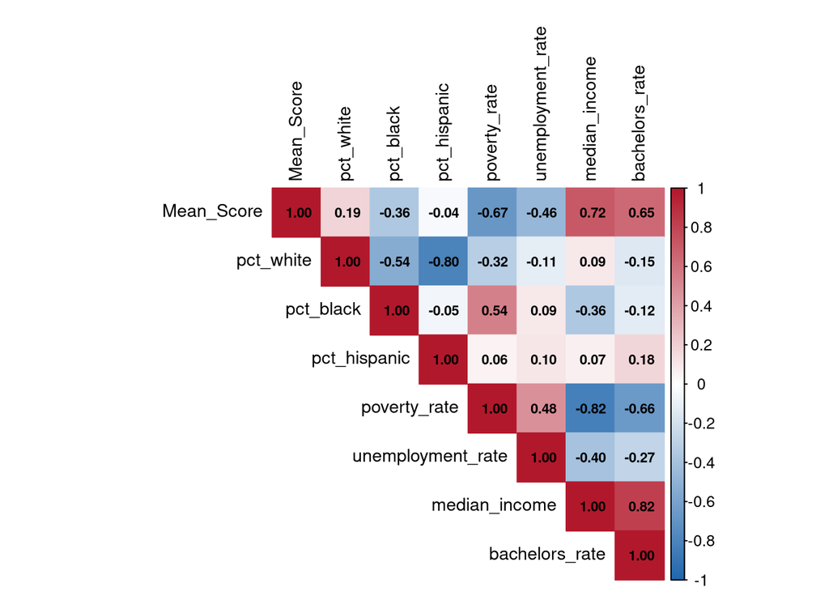

```r
corr_data <- final_data2 %>%
select(
Mean_Score,
pct_white,
pct_black,
pct_hispanic,
poverty_rate,
unemployment_rate,
median_income,
bachelors_rate
)

cor_matrix <- cor(corr_data, use = "pairwise.complete.obs")

corrplot(
cor_matrix,
method = "color",
type = "upper",
tl.cex = 0.9,
tl.col = "black",
number.cex = 0.7,
addCoef.col = "black",
col = colorRampPalette(c("#2166AC", "white", "#B2182B"))(200),
mar = c(0,0,1,0)
)
```

The correlation matrix shows:

- **Strong positive relationships** between achievement, income (r = 0.72), and bachelor’s degree attainment (r = 0.65)
- **Strong negative relationship** between poverty and income (r = –0.82)
- **Strong positive correlation** between income and education (r = 0.82)

These patterns indicate strong multicollinearity among socioeconomic variables, explaining why some variables lose significance in regression models.

This supports Sirin (2005) and Reardon et al. (2019), who describe SES variables as a highly interconnected system rather than independent predictors.

### Quantile Coefficient Plot

**View R Code**

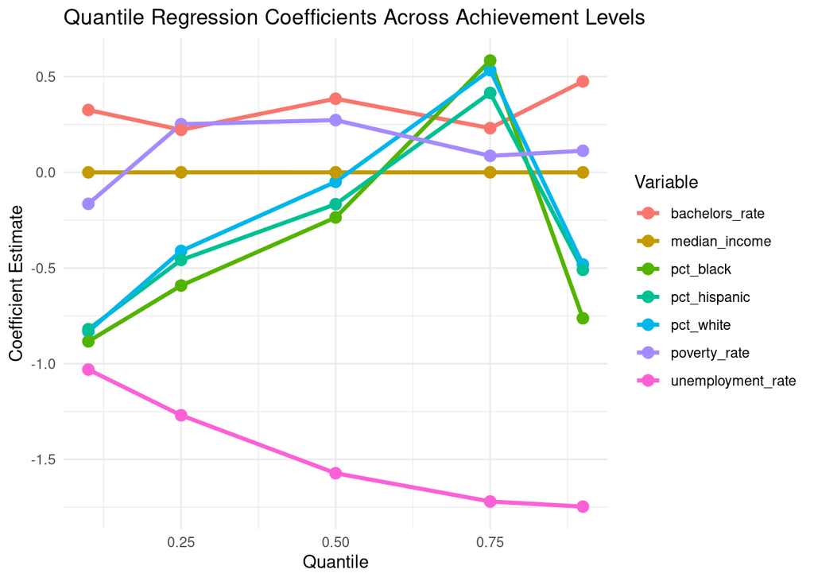

```r
taus <- c(.10, .25, .50, .75, .90)

coef_data <- data.frame(
Quantile = taus,

pct_white = c(
coef(rq10)["pct_white"],
coef(rq25)["pct_white"],
coef(rq50)["pct_white"],
coef(rq75)["pct_white"],
coef(rq90)["pct_white"]
),

pct_black = c(
coef(rq10)["pct_black"],
coef(rq25)["pct_black"],
coef(rq50)["pct_black"],
coef(rq75)["pct_black"],
coef(rq90)["pct_black"]
),

pct_hispanic = c(
coef(rq10)["pct_hispanic"],
coef(rq25)["pct_hispanic"],
coef(rq50)["pct_hispanic"],
coef(rq75)["pct_hispanic"],
coef(rq90)["pct_hispanic"]
),

poverty_rate = c(
coef(rq10)["poverty_rate"],
coef(rq25)["poverty_rate"],
coef(rq50)["poverty_rate"],
coef(rq75)["poverty_rate"],
coef(rq90)["poverty_rate"]
),

unemployment_rate = c(
coef(rq10)["unemployment_rate"],
coef(rq25)["unemployment_rate"],
coef(rq50)["unemployment_rate"],
coef(rq75)["unemployment_rate"],
coef(rq90)["unemployment_rate"]
),

median_income = c(
coef(rq10)["median_income"],
coef(rq25)["median_income"],
coef(rq50)["median_income"],
coef(rq75)["median_income"],
coef(rq90)["median_income"]
),

bachelors_rate = c(
coef(rq10)["bachelors_rate"],
coef(rq25)["bachelors_rate"],
coef(rq50)["bachelors_rate"],
coef(rq75)["bachelors_rate"],
coef(rq90)["bachelors_rate"]
)
)

library(dplyr)
library(tidyr)

coef_long <- coef_data %>%
pivot_longer(
cols = -Quantile,
names_to = "Variable",
values_to = "Coefficient"
)

library(ggplot2)

ggplot(
coef_long,
aes(
x = Quantile,
y = Coefficient,
color = Variable
)
) +
geom_line(linewidth = 1.2) +
geom_point(size = 3) +
labs(
title = "Quantile Regression Coefficients Across Achievement Levels",
x = "Quantile",
y = "Coefficient Estimate"
) +
theme_minimal()
```

This clearly demonstrates heterogeneous effects that are not visible in OLS regression.

Koenker and Bassett (1978), highlight that quantile regression is specifically designed to uncover such distributional differences, which are critical in educational inequality research.

### Summary of Quantile Regression Findings

Overall, the results show:

- Demographic variables matter most in low-achieving districts
- Educational attainment matters most in high-achieving districts
- Unemployment is consistently important across all levels

This confirms that educational inequality is not uniform but varies systematically across the achievement distribution.

## Summary of Findings

Third, the quantile regression models demonstrated that the magnitude and direction of several predictor effects varied across the achievement distribution. These differences were not apparent in the OLS model, which estimated only average relationships. Finally, bachelor’s degree attainment emerged as the strongest positive predictor among higher-achieving districts, whereas unemployment was the most consistent negative predictor across the distribution. These findings support the use of quantile regression for identifying differences in educational inequality that may not be detected using traditional mean-based regression methods.

### Policy Implications

The findings of this study have several practical implications for educational leaders, policymakers, and school districts. Because the relationships between community characteristics and Algebra 1 achievement differ across the achievement distribution, the results suggest that improvement efforts should be tailored to the specific needs of districts rather than relying on a single statewide approach.

#### Target Economic Instability

Unemployment is one of the most consistent predictors of Algebra 1 achievement, remaining negative across all quantiles and statistically significant in the OLS model ($p = 0.0203$).

This suggests that economic instability affects student learning regardless of district performance level. Districts experiencing high unemployment should therefore receive targeted support, including tutoring programs, attendance interventions, and mental health services.

This aligns with Duncan and Murnane (2016), who show that economic instability disrupts learning environments and reduces academic performance.

#### Strengthen Educational Capital in Communities

Bachelor’s degree attainment is the strongest positive predictor, especially in higher-achieving districts ($0.47533$ at $\tau = .90$).

This indicates that community educational attainment plays a key role in sustaining academic success.

Policies should therefore support adult education, workforce training, community college access, and family learning initiatives.

This is consistent with Sirin (2005) and Reardon et al. (2019), who emphasize the importance of parental education in shaping long-term educational outcomes.

#### Focus Intensive Support on Low-Achieving Districts

These districts require more intensive interventions such as:

- Smaller class sizes
- High-dosage tutoring
- Extended learning time
- Wraparound student services

This supports Fryer et al. (2015), who find that targeted interventions are most effective in high-poverty settings.

#### Avoid One-Size-Fits-All Policies

The results clearly show that predictor effects differ across achievement levels:

- Demographic effects are strongest in low-performing districts
- Educational attainment dominates in high-performing districts
- Unemployment is consistently important

This means that uniform policies may fail to address local needs.

Bryk (2015) argue that effective school improvement must be context-specific, which is strongly supported by these findings.

#### Cross-Sector Policy Integration

The strong correlations among poverty, income, and education indicate that achievement is shaped by broader community systems.

Improving outcomes therefore requires coordination between:

- Education systems
- Workforce development
- Housing policy
- Public health services

This supports Reardon et al. (2019) and Owens (2017), who emphasize that achievement gaps are rooted in structural inequality beyond schools.

### Contribution of the Study

This study makes several important contributions to educational research. First, it applies quantile regression to examine district-level Algebra 1 End-of-Course achievement in Florida, extending previous studies that have primarily relied on average-based regression methods. Second, the findings show that demographic and socioeconomic characteristics do not influence achievement uniformly across school districts. Instead, the strength of these relationships varies across the achievement distribution. Third, the study demonstrates that unemployment and bachelor’s degree attainment are more consistent predictors of achievement than poverty or demographic composition after accounting for other district characteristics. Finally, the study illustrates how quantile regression can provide a more complete understanding of educational inequality and support the development of more targeted educational policies.

### Limitations

This study has several limitations. First, the analysis is based on cross-sectional data, meaning that the results describe statistical associations rather than cause-and-effect relationships. Second, the analysis was conducted at the district level using county-based demographic and socioeconomic measures. Therefore, the findings should not be interpreted as applying directly to individual students. Third, only variables available from the Florida Department of Education and the American Community Survey were included in the analysis. Other school-level characteristics, such as teacher experience, instructional quality, attendance, school funding, and class size, were not available. Finally, the study includes only Florida school districts, and the findings may not generalize to states with different educational policies or demographic characteristics.

### Recommendations for Future Research

Future research should examine these relationships using longitudinal data to determine how demographic and socioeconomic factors influence Algebra 1 achievement over time. Studies that combine student level, school level, and district level data would provide a more comprehensive understanding of educational inequality. Future research should also include additional school characteristics, such as teacher qualifications, attendance, instructional resources, and per-pupil funding. Finally, similar analyses should be conducted in other states to determine whether the patterns identified in Florida are consistent across different educational systems.

## Conclusion

This study examined the relationship between demographic and socioeconomic characteristics and Algebra 1 End-of-Course achievement across Florida school districts using both OLS and quantile regression.

The findings show that socioeconomic factors especially unemployment and educational attainment are the most consistent predictors of achievement.

Although poverty and income show strong bivariate relationships with achievement, their effects are largely explained by other socioeconomic variables.

The quantile regression results demonstrate that educational inequality is not uniform. Instead, predictor effects vary across the achievement distribution, with demographic variables being most important in low-performing districts and educational attainment being most important in high-performing districts.

Overall, the study highlights the importance of using distribution-sensitive methods such as quantile regression to better understand educational inequality and to design more targeted and effective policy interventions.

**View R Code**

```r
saveRDS(final_data2, "final_data2.rds")
```

## References

Beyerlein, Andreas. 2014. “Quantile Regression—Opportunities and Challenges from a User’s Perspective.” *American Journal of Epidemiology* 180 (3): 330–31. https://doi.org/10.1093/aje/kwu178.

Bryk, Anthony S. 2015. “2014 AERA Distinguished Lecture: Accelerating How We Learn to Improve.” *Educational Researcher* 44 (9): 467–77. https://doi.org/10.3102/0013189X15621543.

Buhai, I. Sebastian. 2004. *Quantile Regression: Overview and Selected Applications*. Report. Tinbergen Institute; Erasmus University Rotterdam.

Costanzo, Antonella, and Marta Desimoni. 2017. “Beyond the Mean Estimate: A Quantile Regression Analysis of Inequalities in Educational Outcomes Using INVALSI Survey Data.” *Large-Scale Assessments in Education* 5 (1): 14. https://doi.org/10.1186/s40536-017-0048-4.

Davino, Cristina, Marilena Furno, and Domenico Vistocco. 2013. *Quantile Regression: Theory and Applications*. John Wiley & Sons.

Duncan, Greg J., and Richard J. Murnane. 2016. “Rising Inequality in Family Incomes and Children’s Educational Outcomes.” *RSF: The Russell Sage Foundation Journal of the Social Sciences* 2 (2): 142–58. https://doi.org/10.7758/RSF.2016.2.2.06.

Fryer, Roland G., Jr., Steven D. Levitt, and John A. List. 2015. *Parental Incentives and Early Childhood Achievement: A Field Experiment in Chicago Heights*. Working Paper No. 21477. National Bureau of Economic Research. https://doi.org/10.3386/w21477.

Haile, Getinet Astatike, and Anh Ngoc Nguyen. 2008. “Determinants of Academic Attainment in the United States: A Quantile Regression Analysis of Test Scores.” *Education Economics* 16 (1): 29–57. https://doi.org/10.1080/09645290701523218.

Holley, Hope D. 2017. “A Quantitative Study Analyzing Predictive Factors That Affect Achievement on Florida’s Algebra i End-of-Course Exam (EOC).” Doctoral dissertation, Florida Southern College.

Koenker, Roger, and Gilbert Bassett Jr. 1978. “Regression Quantiles.” *Econometrica* 46 (1): 33–50. https://doi.org/10.2307/1913643.

Koenker, Roger, and Kevin F. Hallock. 2001. “Quantile Regression.” *Journal of Economic Perspectives* 15 (4): 143–56. https://doi.org/10.1257/jep.15.4.143.

Koenker, Roger, and Pin Ng. 2005. “Inequality Constrained Quantile Regression.” *Sankhyā: The Indian Journal of Statistics* 67 (2): 418–40.

Lê Cook, Benjamin, and Willard G. Manning. 2013. “Thinking Beyond the Mean: A Practical Guide for Using Quantile Regression Methods for Health Services Research.” *Shanghai Archives of Psychiatry* 25 (1): 55–59. https://doi.org/10.3969/j.issn.1002-0829.2013.01.011.

Owens, Ann. 2017. “Income Segregation Between School Districts and Inequality in Students’ Achievement.” *Sociology of Education* 91 (1): 1–27. https://doi.org/10.1177/0038040717741180.

Petscher, Yaacov, and Jessica A. R. Logan. 2014. “Quantile Regression in the Study of Developmental Sciences.” *Child Development* 85 (3): 861–81. https://doi.org/10.1111/cdev.12190.

Reardon, Sean F., Demetra Kalogrides, and Kenneth Shores. 2019. “The Geography of Racial/Ethnic Test Score Gaps.” *American Journal of Sociology* 124 (4): 1164–221. https://doi.org/10.1086/700678.

Reeves, Edward B., and Jesse Lowe. 2009. “Quantile Regression: An Education Policy Research Tool.” *Journal of Rural Social Sciences* 24 (1): Article 10. https://egrove.olemiss.edu/jrss/vol24/iss1/10.

Sirin, Selcuk R. 2005. “Socioeconomic Status and Academic Achievement: A Meta-Analytic Review of Research.” *Review of Educational Research* 75 (3): 417–53. https://doi.org/10.3102/00346543075003417.

Tian, Maozai. 2006. “A Quantile Regression Analysis of Family Background Factor Effects on Mathematical Achievement.” *Journal of Data Science* 4 (4): 461–78.

Waldmann, Elisabeth. 2018. “Quantile Regression: A Short Story on How and Why.” *Statistical Modelling* 18 (3–4): 203–18. https://doi.org/10.1177/1471082X18759142.